# NYPD Shooting Incident Data

Iaroslav Grushetskyi

2024-08-02

```r
knitr::opts_chunk$set(echo = TRUE)
```

#### 1. Loading the packages.

```r
library(magrittr)
library(dplyr)
library(lubridate)
```

```r
library(ggplot2)
```

#### 2. Reading the Data.

```r
url <- "https://data.cityofnewyork.us/api/views/833y-fsy8/rows.csv?accessType=DOWNLOAD"
nypd <- read.csv(url, header = TRUE, stringsAsFactors = FALSE)
glimpse(nypd)
```

```
## Rows: 28,562
## Columns: 21
## $ INCIDENT_KEY            <int> 244608249, 247542571, 84967535, 202853370, 270…
## $ OCCUR_DATE              <chr> "05/05/2022", "07/04/2022", "05/27/2012", "09/…
## $ OCCUR_TIME              <chr> "00:10:00", "22:20:00", "19:35:00", "21:00:00"…
## $ BORO                    <chr> "MANHATTAN", "BRONX", "QUEENS", "BRONX", "BROO…
## $ LOC_OF_OCCUR_DESC       <chr> "INSIDE", "OUTSIDE", "", "", "", "", "", "", "…
## $ PRECINCT                <int> 14, 48, 103, 42, 83, 23, 113, 77, 48, 49, 73, …
## $ JURISDICTION_CODE       <int> 0, 0, 0, 0, 0, 2, 0, 0, 0, 0, 0, 0, 0, 0, 0, 0…
## $ LOC_CLASSFCTN_DESC      <chr> "COMMERCIAL", "STREET", "", "", "", "", "", ""…
## $ LOCATION_DESC           <chr> "VIDEO STORE", "(null)", "", "", "", "MULTI DW…
## $ STATISTICAL_MURDER_FLAG <chr> "true", "true", "false", "false", "false", "fa…
## $ PERP_AGE_GROUP          <chr> "25-44", "(null)", "", "25-44", "25-44", "", "…
## $ PERP_SEX                <chr> "M", "(null)", "", "M", "M", "", "", "", "", "…
## $ PERP_RACE               <chr> "BLACK", "(null)", "", "UNKNOWN", "BLACK", "",…
## $ VIC_AGE_GROUP           <chr> "25-44", "18-24", "18-24", "25-44", "25-44", "…
## $ VIC_SEX                 <chr> "M", "M", "M", "M", "M", "M", "M", "M", "M", "…
## $ VIC_RACE                <chr> "BLACK", "BLACK", "BLACK", "BLACK", "BLACK", "…
## $ X_COORD_CD              <dbl> 986050, 1016802, 1048632, 1014493, 1009149, 99…
## $ Y_COORD_CD              <dbl> 214231.0, 250581.0, 198262.0, 242565.0, 190104…
## $ Latitude                <dbl> 40.75469, 40.85440, 40.71063, 40.83242, 40.688…
## $ Longitude               <dbl> -73.99350, -73.88233, -73.76777, -73.89071, -7…
## $ Lon_Lat                 <chr> "POINT (-73.9935 40.754692)", "POINT (-73.8823…
```

##### The data contains 28562 observations and 21 variables of different types. Missing and null values are also present.

#### 3. Summary of the columns.

##### Reading the basic statistics.

```r
summary(nypd)
```

```
##   INCIDENT_KEY        OCCUR_DATE         OCCUR_TIME            BORO
##  Min.   :  9953245   Length:28562       Length:28562       Length:28562
##  1st Qu.: 65439914   Class :character   Class :character   Class :character
##  Median : 92711254   Mode  :character   Mode  :character   Mode  :character
##  Mean   :127405824
##  3rd Qu.:203131993
##  Max.   :279758069
##
##  LOC_OF_OCCUR_DESC     PRECINCT     JURISDICTION_CODE LOC_CLASSFCTN_DESC
##  Length:28562       Min.   :  1.0   Min.   :0.0000    Length:28562
##  Class :character   1st Qu.: 44.0   1st Qu.:0.0000    Class :character
##  Mode  :character   Median : 67.0   Median :0.0000    Mode  :character
##                     Mean   : 65.5   Mean   :0.3219
##                     3rd Qu.: 81.0   3rd Qu.:0.0000
##                     Max.   :123.0   Max.   :2.0000
##                                     NA's   :2
##  LOCATION_DESC      STATISTICAL_MURDER_FLAG PERP_AGE_GROUP
##  Length:28562       Length:28562            Length:28562
##  Class :character   Class :character        Class :character
##  Mode  :character   Mode  :character        Mode  :character
##
##
##
##
##    PERP_SEX          PERP_RACE         VIC_AGE_GROUP        VIC_SEX
##  Length:28562       Length:28562       Length:28562       Length:28562
##  Class :character   Class :character   Class :character   Class :character
##  Mode  :character   Mode  :character   Mode  :character   Mode  :character
##
##
##
##
##    VIC_RACE           X_COORD_CD        Y_COORD_CD        Latitude
##  Length:28562       Min.   : 914928   Min.   :125757   Min.   :40.51
##  Class :character   1st Qu.:1000068   1st Qu.:182912   1st Qu.:40.67
##  Mode  :character   Median :1007772   Median :194901   Median :40.70
##                     Mean   :1009424   Mean   :208380   Mean   :40.74
##                     3rd Qu.:1016807   3rd Qu.:239814   3rd Qu.:40.82
##                     Max.   :1066815   Max.   :271128   Max.   :40.91
##                                                        NA's   :59
##    Longitude        Lon_Lat
##  Min.   :-74.25   Length:28562
##  1st Qu.:-73.94   Class :character
##  Median :-73.92   Mode  :character
##  Mean   :-73.91
##  3rd Qu.:-73.88
##  Max.   :-73.70
##  NA's   :59
```

##### The summary provides essential statistics of the variables, with particular focus on numeric variables. In our data set, most columns are of character type and do not contain significant statistical information.

#### 4. Removing unnecessary columns.

```r
remove_columns <- c('LOC_OF_OCCUR_DESC',
                    'JURISDICTION_CODE',
                    'LOC_CLASSFCTN_DESC',
                    'X_COORD_CD',
                    'Y_COORD_CD',
                    'Latitude',
                    'Longitude')
nypd <- nypd %>% select(-contains(remove_columns))
glimpse(nypd)
```

```
## Rows: 28,562
## Columns: 14
## $ INCIDENT_KEY            <int> 244608249, 247542571, 84967535, 202853370, 270…
## $ OCCUR_DATE              <chr> "05/05/2022", "07/04/2022", "05/27/2012", "09/…
## $ OCCUR_TIME              <chr> "00:10:00", "22:20:00", "19:35:00", "21:00:00"…
## $ BORO                    <chr> "MANHATTAN", "BRONX", "QUEENS", "BRONX", "BROO…
## $ PRECINCT                <int> 14, 48, 103, 42, 83, 23, 113, 77, 48, 49, 73, …
## $ LOCATION_DESC           <chr> "VIDEO STORE", "(null)", "", "", "", "MULTI DW…
## $ STATISTICAL_MURDER_FLAG <chr> "true", "true", "false", "false", "false", "fa…
## $ PERP_AGE_GROUP          <chr> "25-44", "(null)", "", "25-44", "25-44", "", "…
## $ PERP_SEX                <chr> "M", "(null)", "", "M", "M", "", "", "", "", "…
## $ PERP_RACE               <chr> "BLACK", "(null)", "", "UNKNOWN", "BLACK", "",…
## $ VIC_AGE_GROUP           <chr> "25-44", "18-24", "18-24", "25-44", "25-44", "…
## $ VIC_SEX                 <chr> "M", "M", "M", "M", "M", "M", "M", "M", "M", "…
## $ VIC_RACE                <chr> "BLACK", "BLACK", "BLACK", "BLACK", "BLACK", "…
## $ Lon_Lat                 <chr> "POINT (-73.9935 40.754692)", "POINT (-73.8823…
```

##### Even though the columns above can be used for analysis, I have decided to remove them for this report.

#### 5. Change date column to date type.

```r
nypd$OCCUR_DATE <- mdy(nypd$OCCUR_DATE)
```

#### 6. Structure of the columns.

```r
str(nypd)
```

```
## 'data.frame':    28562 obs. of  14 variables:
##  $ INCIDENT_KEY           : int  244608249 247542571 84967535 202853370 27078636 230311078 229224142 231246224 228559720 238210279 ...
##  $ OCCUR_DATE             : Date, format: "2022-05-05" "2022-07-04" ...
##  $ OCCUR_TIME             : chr  "00:10:00" "22:20:00" "19:35:00" "21:00:00" ...
##  $ BORO                   : chr  "MANHATTAN" "BRONX" "QUEENS" "BRONX" ...
##  $ PRECINCT               : int  14 48 103 42 83 23 113 77 48 49 ...
##  $ LOCATION_DESC          : chr  "VIDEO STORE" "(null)" "" "" ...
##  $ STATISTICAL_MURDER_FLAG: chr  "true" "true" "false" "false" ...
##  $ PERP_AGE_GROUP         : chr  "25-44" "(null)" "" "25-44" ...
##  $ PERP_SEX               : chr  "M" "(null)" "" "M" ...
##  $ PERP_RACE              : chr  "BLACK" "(null)" "" "UNKNOWN" ...
##  $ VIC_AGE_GROUP          : chr  "25-44" "18-24" "18-24" "25-44" ...
##  $ VIC_SEX                : chr  "M" "M" "M" "M" ...
##  $ VIC_RACE               : chr  "BLACK" "BLACK" "BLACK" "BLACK" ...
##  $ Lon_Lat                : chr  "POINT (-73.9935 40.754692)" "POINT (-73.88233 40.854402)" "POINT (-73.76777349199995 40.71063412500007)" "POINT (-73.89071440599997 40.832416753000075)" ...
```

##### The structure function tells us the type of the data values and size.

#### 7. Missing values.

##### Handling missing values in data is crucial. Depending on the type of data, various methods can be applied. In this data set, columns with missing values are of character or factor type. Removing these rows would discard other valuable information. Therefore, I have populated the missing, non-numeric values with “UNKNOWN”.

```r
age_groups <- c("<18", "18-24", "25-44", "45-64", "65+")
nypd$PERP_RACE[nypd$PERP_RACE == "" | nypd$PERP_RACE == "(null)"] <- "UNKNOWN"
nypd$PERP_SEX[nypd$PERP_SEX == "" | nypd$PERP_SEX == "(null)" | nypd$PERP_SEX == "U"] <- "UNKNOWN"
nypd$VIC_SEX[nypd$VIC_SEX == "" | nypd$VIC_SEX == "(null)" | nypd$VIC_SEX == "U"] <- "UNKNOWN"
nypd$PERP_AGE_GROUP[!nypd$PERP_AGE_GROUP %in% age_groups] <- "UNKNOWN"
nypd$VIC_AGE_GROUP[!nypd$VIC_AGE_GROUP %in% age_groups] <- "UNKNOWN"
nypd$LOCATION_DESC[nypd$LOCATION_DESC == "" | nypd$LOCATION_DESC == "(null)" | nypd$LOCATION_DESC == "NONE"] <- "UNKNOWN"
glimpse(nypd)
```

```
## Rows: 28,562
## Columns: 14
## $ INCIDENT_KEY            <int> 244608249, 247542571, 84967535, 202853370, 270…
## $ OCCUR_DATE              <date> 2022-05-05, 2022-07-04, 2012-05-27, 2019-09-2…
## $ OCCUR_TIME              <chr> "00:10:00", "22:20:00", "19:35:00", "21:00:00"…
## $ BORO                    <chr> "MANHATTAN", "BRONX", "QUEENS", "BRONX", "BROO…
## $ PRECINCT                <int> 14, 48, 103, 42, 83, 23, 113, 77, 48, 49, 73, …
## $ LOCATION_DESC           <chr> "VIDEO STORE", "UNKNOWN", "UNKNOWN", "UNKNOWN"…
## $ STATISTICAL_MURDER_FLAG <chr> "true", "true", "false", "false", "false", "fa…
## $ PERP_AGE_GROUP          <chr> "25-44", "UNKNOWN", "UNKNOWN", "25-44", "25-44…
## $ PERP_SEX                <chr> "M", "UNKNOWN", "UNKNOWN", "M", "M", "UNKNOWN"…
## $ PERP_RACE               <chr> "BLACK", "UNKNOWN", "UNKNOWN", "UNKNOWN", "BLA…
## $ VIC_AGE_GROUP           <chr> "25-44", "18-24", "18-24", "25-44", "25-44", "…
## $ VIC_SEX                 <chr> "M", "M", "M", "M", "M", "M", "M", "M", "M", "…
## $ VIC_RACE                <chr> "BLACK", "BLACK", "BLACK", "BLACK", "BLACK", "…
## $ Lon_Lat                 <chr> "POINT (-73.9935 40.754692)", "POINT (-73.8823…
```

#### 8. Visualizing the Data.

##### Shootings by Year

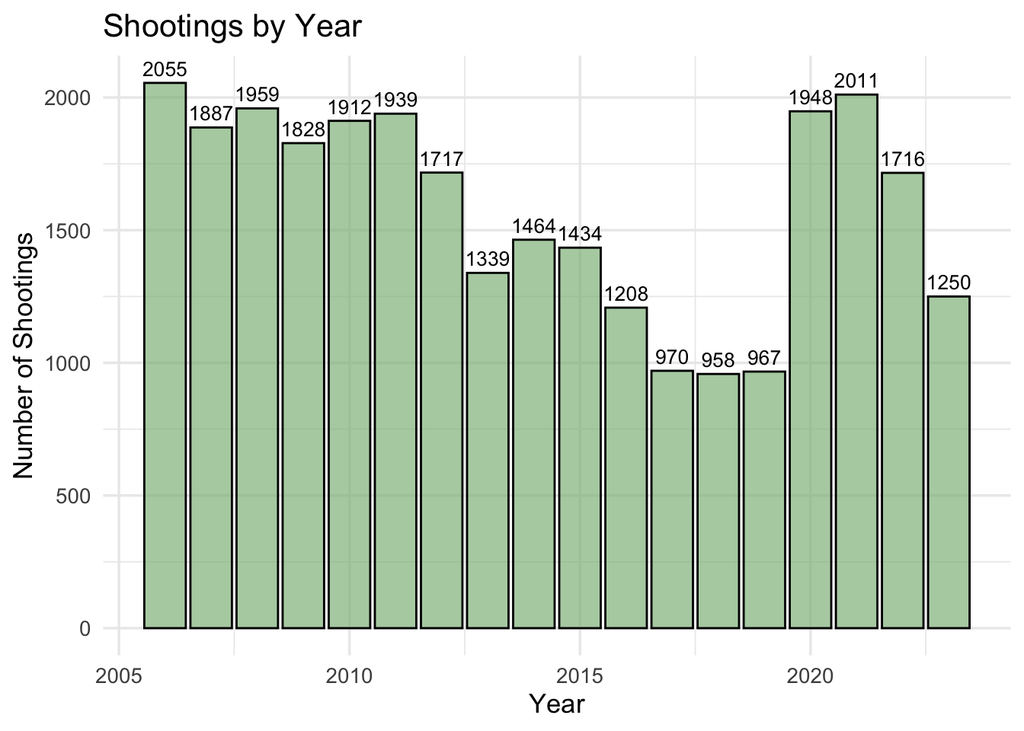

```r
shootings_by_year <- as.data.frame(table(nypd %>% select(OCCUR_DATE))) %>%
  group_by(year = lubridate::year(OCCUR_DATE)) %>%
  summarise(sum_of_shootings = sum(Freq))
ggplot(shootings_by_year, aes(x = year, y = sum_of_shootings)) +
  geom_col(fill = '#8FBC8B', color = 'black', alpha = 0.7) +
  labs(title = "Shootings by Year", x = "Year", y = "Number of Shootings") +
  geom_text(aes(label = sum_of_shootings), position=position_dodge(width=0.9), vjust = -0.5, size = 3.5) +
  theme_bw(base_size = 10) + theme_minimal(base_size = 13)
```

##### Shootings by Borough.

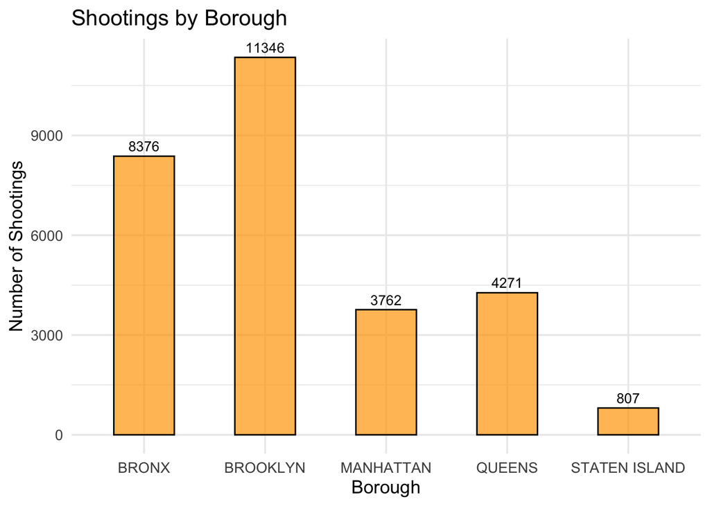

```r
boro <- as.data.frame(table(nypd %>% select(BORO)))
ggplot(data = boro, aes(x = BORO, y = Freq)) +
  geom_bar(stat = "identity", fill = 'orange', color = 'black', width = 0.5, alpha = 0.7) +
  labs(title = "Shootings by Borough", x = "Borough", y = "Number of Shootings") +
  geom_text(aes(label = Freq), position=position_dodge(width=0.9), vjust = -0.5, size = 3.5) +
  theme_bw(base_size = 10) + theme_minimal(base_size = 13)
```

##### The majority of shootings occurred in Brooklyn, while Staten Island had the fewest incidents.

##### Fatal Shootings.

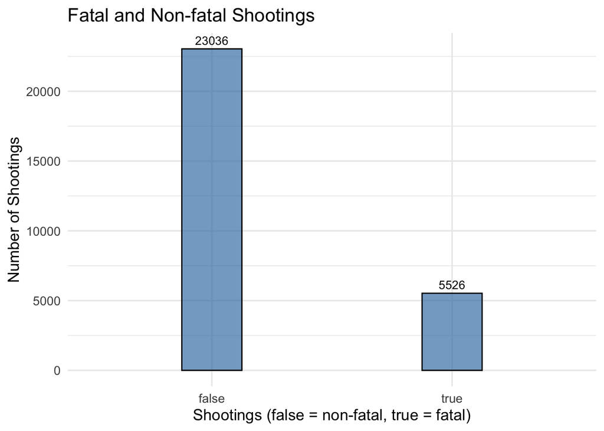

```r
fatal_and_nonfatal <- as.data.frame(table(nypd %>% select(STATISTICAL_MURDER_FLAG)))
ggplot(data = fatal_and_nonfatal, aes(x = STATISTICAL_MURDER_FLAG, y = Freq)) +
  geom_bar(stat = "identity", fill = 'steelblue', color = 'black', width = 0.25, alpha = 0.7) +
  labs(title = "Fatal and Non-fatal Shootings ", x = "Shootings (false = non-fatal, true = fatal)", y = "Number of Shootings") +
  geom_text(aes(label = Freq), position=position_dodge(width=0.9), vjust = -0.5, size = 3.5) +
  theme_bw(base_size = 10) + theme_minimal(base_size = 13)
```

##### The majority of the shootings did not result in fatalities. However, slightly over 5,000 incidents were fatal and are classified as murders.

##### Shootings by Perpetrator Age Group.

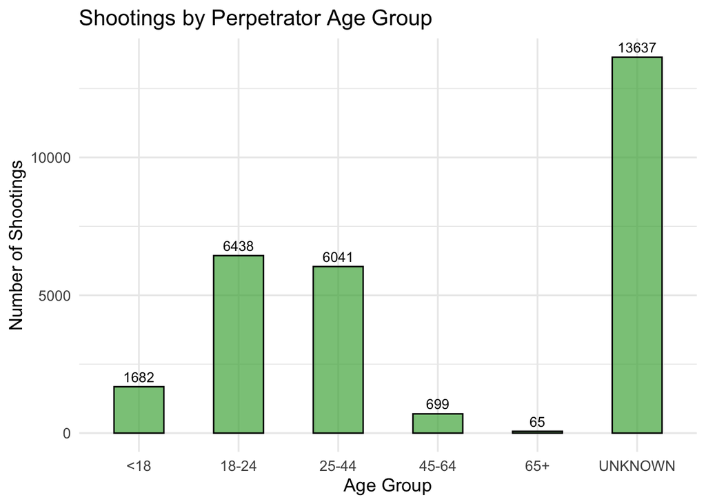

```r
perp_age_grp <- as.data.frame(table(nypd %>% select(PERP_AGE_GROUP)))
ggplot(data = perp_age_grp, aes(x = PERP_AGE_GROUP, y = Freq)) +
  geom_bar(stat = "identity", fill = '#4DAF4A', color = 'black', width = 0.5, alpha = 0.7) +
  labs(title = "Shootings by Perpetrator Age Group", x = "Age Group", y = "Number of Shootings") +
  geom_text(aes(label = Freq), position=position_dodge(width=0.9), vjust = -0.5, size = 3.5) +
  theme_bw(base_size = 10) + theme_minimal(base_size = 13)
```

##### The majority of shootings were committed by individuals aged 18-24 and 25-44. However, the “UNKNOWN” category contains a significant amount of data, which could impact the distribution across all age groups if properly identified.

##### Fatal Outcomes in each Borough.

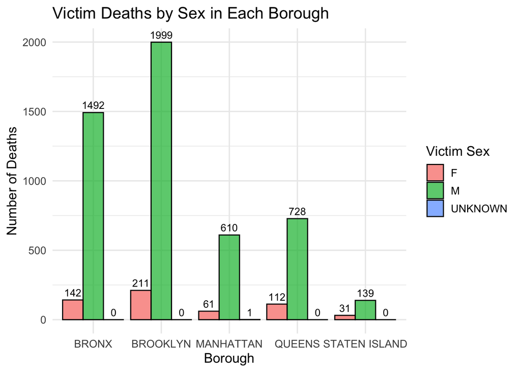

```r
deaths <- as.data.frame(table(nypd %>%
  select(BORO, STATISTICAL_MURDER_FLAG, VIC_SEX)%>%
  filter(STATISTICAL_MURDER_FLAG=="true")))
ggplot(data = deaths, aes(x = BORO, y = Freq, fill = VIC_SEX)) +
  geom_bar(stat = "identity", position = "dodge", color = "black", alpha = 0.7) +
  labs(title = "Victim Deaths by Sex in Each Borough",
         x = "Borough", y = "Number of Deaths", fill = "Victim Sex") +
  geom_text(aes(label = Freq), position=position_dodge(width=0.9), vjust = -0.5, size = 3.5) +
  theme_bw(base_size = 9) + theme_minimal(base_size = 13)
```

##### The majority of fatal shootings occurred in Brooklyn, with male victims being predominant.

##### Shootings by Perpetrator’s Sex in each Borough.

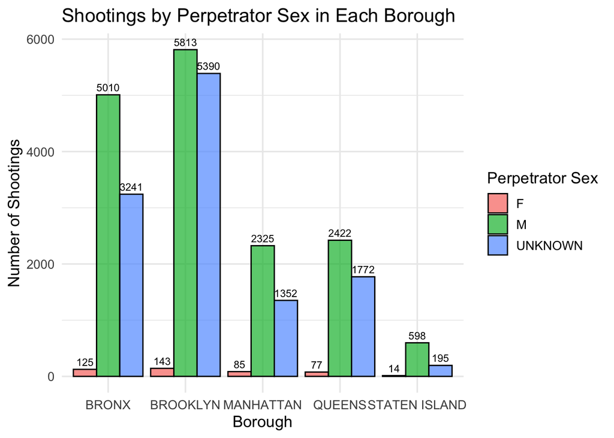

```r
shoot_perp_sex <- as.data.frame(table(nypd %>%
  select(BORO, PERP_SEX)))
ggplot(data = shoot_perp_sex, aes(x = BORO, y = Freq, fill = PERP_SEX)) +
  geom_bar(stat = "identity", position = "dodge", color = "black", alpha = 0.7) +
  labs(title = "Shootings by Perpetrator Sex in Each Borough",
         x = "Borough", y = "Number of Shootings", fill = "Perpetrator Sex") +
  geom_text(aes(label = Freq), position=position_dodge(width=0.9), vjust = -0.5, size = 3) +
  theme_bw(base_size = 10) + theme_minimal(base_size = 13)
```

##### Brooklyn continues to have the highest number of shootings involving male perpetrators, with the ‘UNKNOWN’ category showing a comparable amount of data. Additionally, there is a significant disparity between the number of male and female perpetrators.

#### 9. Logistic Regression Model.

##### In this section I use Logistic Regression model to predict an outcome of the shootings based on victim’s age.

```r
shoot_outcome_vicsex <- data.frame(
  age = as.factor(nypd$VIC_AGE_GROUP),
  shoot_outcome = ifelse(nypd$STATISTICAL_MURDER_FLAG == "true", TRUE, FALSE)
)
```

##### The Model.

```r
log_reg_model <- glm(formula = shoot_outcome ~ age, family = "binomial", data = shoot_outcome_vicsex)
summary(log_reg_model)
```

```
##
## Call:
## glm(formula = shoot_outcome ~ age, family = "binomial", data = shoot_outcome_vicsex)
##
## Coefficients:
##             Estimate Std. Error z value Pr(>|z|)
## (Intercept) -1.89803    0.05465 -34.730  < 2e-16 ***
## age18-24     0.28813    0.06066   4.750 2.04e-06 ***
## age25-44     0.62513    0.05863  10.662  < 2e-16 ***
## age45-64     0.79065    0.07544  10.481  < 2e-16 ***
## age65+       1.15321    0.15916   7.246 4.31e-13 ***
## ageUNKNOWN   0.69406    0.29942   2.318   0.0204 *
## ---
## Signif. codes:  0 '***' 0.001 '**' 0.01 '*' 0.05 '.' 0.1 ' ' 1
##
## (Dispersion parameter for binomial family taken to be 1)
##
##     Null deviance: 28061  on 28561  degrees of freedom
## Residual deviance: 27821  on 28556  degrees of freedom
## AIC: 27833
##
## Number of Fisher Scoring iterations: 4
```

```r
predict_model <- predict(log_reg_model, newdata = shoot_outcome_vicsex, type = "response")
table(predict_model, nypd$VIC_AGE_GROUP)
```

```
##
## predict_model         <18 18-24 25-44 45-64   65+ UNKNOWN
##   0.130331753555403  2954     0     0     0     0       0
##   0.166602465331273     0 10384     0     0     0       0
##   0.218762044245934     0     0 12973     0     0       0
##   0.230769230769578     0     0     0     0     0      65
##   0.248359414437665     0     0     0  1981     0       0
##   0.321951219512248     0     0     0     0   205       0
```

##### Above is the prediction table with the probabilities of a fatal outcome for each age group, where the same data was used on itself.

#### 10. Bias Identification.

##### In this section I illustrate potential personal biases and methods to mitigate them. Identifying and understanding biases is an important step to ensure an objective and fair interpretation of the data. Here is some of the potential biases and mitigating methods:

##### -Confirmation Bias: The tendency to search for, interpret, and remember information that confirms one’s preconceptions.

##### -Cultural Bias: Preferences or prejudices rooted in one’s cultural background can affect how data is interpreted.

##### -Anchoring Bias: Over-reliance on the first piece of information encountered.

##### -Implicit Bias: Unconscious attitudes or stereotypes that affect understanding, actions, and decisions.

##### Some of the mitigating methods include, but not limited to, are:

##### -Acknowledging and educating oneself about common biases and their effect on data.

##### -Use of statistical techniques to check and adjust potential biases.

##### -Use of standardized methods to reduce subjectivity.

##### -Peer Review: Have the analysis reviewed by others who can provide an objective critique.

##### -Reflective Practice: Regularly reflect on one’s own biases and how they might be influencing the analysis.

#### Conclusive Remarks.

##### Analyzing NYPD shootings data provided valuable hands-on experience with basic analytic methods in the R environment. I utilized libraries for data pre processing and manipulation, created visual presentations, and conducted basic statistical modeling. The Logistic Regression section offered an initial predictive overview of the data. However, for more accurate results, implementing more robust pre processing techniques is recommended. This report outlines the essential data analysis steps, emphasizing the importance of reproducibility.